# DATA 607 Project 4: Text Mining

Ilya Kats

April 16, 2017

## Introduction

The original assignment called for modeling and categorization of a spam/ham email set. I wanted to practice data scraping some more, so I have decided to pick a different data set. I have settled on reviewing movie plots and categorizing them by genre.

## Required Libraries

```r
# For data scraping
library(XML)
library(RCurl)
library(urltools)
library(tidyjson)

# For data tidying
library(dplyr)
library(tidyr)
library(stringr)

# For data mining
library(tidytext)
library(RTextTools)

# For data graphing
library(ggplot2)
library(gridExtra)
```

## Data Scraping: Part I

### Collecting List of Films

It would not be practical for this assignment to try to collect a very large data set. I needed a movie list that I can use to base my collection on and American Film Institute’s **100 Years…** series popped into my mind. AFI released lists of 100 notable movies in various categories from 1998 to 2008. I have used a Wikipedia [article](https://en.wikipedia.org/wiki/AFI_100_Years..._series) about the series as my starting point.

```r
# Get the main URL and read in the HTML text
urlRoot <- "https://en.wikipedia.org"
urlMain <- "/wiki/AFI_100_Years..._series"
links <- getURL(str_c(urlRoot, urlMain))
links <- htmlParse(links)

# Read the links to all lists
links <- xpathSApply(links, "//div[@id='mw-content-text']//table[@class='infobox']//a", xmlGetAttr, "href")

# Several of collected links were extraneous
# Remove them by finding only links without the term 'Template'
links <- links[str_detect(links, "^((?!Template).)*$")]
```

Collected links are in the table below.

| /wiki/AFI%27s_100_Years…100_Movies |
| --- |
| /wiki/AFI%27s_100_Years…100_Stars |
| /wiki/AFI%27s_100_Years…100_Laughs |
| /wiki/AFI%27s_100_Years…100_Thrills |
| /wiki/AFI%27s_100_Years…100_Passions |
| /wiki/AFI%27s_100_Years…100_Heroes_%26_Villains |
| /wiki/AFI%27s_100_Years…100_Songs |
| /wiki/AFI%27s_100_Years…100_Movie_Quotes |
| /wiki/AFI%27s_100_Years_of_Film_Scores |
| /wiki/AFI%27s_100_Years…100_Cheers |
| /wiki/AFI%27s_Greatest_Movie_Musicals |
| /wiki/AFI%27s_100_Years…100_Movies_(10th_Anniversary_Edition) |
| /wiki/AFI%27s_10_Top_10 |

Now I will loop through all lists and collect individual film tables form each.

```r
# Create empty data frame to store list of films
films <- data.frame(film=character(), year=integer())

# Loop through all links with the exception of last one
for(i in 1:(length(links)-1)) {
  # Get URL and read HTML table
  url <- getURL(str_c(urlRoot, links[i]))
  tmp <- readHTMLTable(url, which = 2)

  # If table contains two columns - Film and Year - then proceed
  if (any(str_detect(str_to_lower(colnames(tmp)), "film")) &&
      any(str_detect(str_to_lower(colnames(tmp)), "year"))) {
    # Isolate columns containing film name and release year
    tmp <- tmp[, c(which(str_detect(str_to_lower(colnames(tmp)), "film")),
                   which(str_detect(str_to_lower(colnames(tmp)), "year")))]
    colnames(tmp) <- c("film", "year")

    # Store discovered films in main data frame
    films <- rbind(films, tmp)
  }
}

# The last link is special as it contains 10 tables of 10 films
# rather than 1 table of 100 films
# Loop through all 10 tables
# Same logic as in the loop above
for(i in 2:11) {
  url <- getURL(str_c(urlRoot, links[length(links)]))
  tmp <- readHTMLTable(url, which = i)
  if (any(str_detect(str_to_lower(colnames(tmp)), "film")) &&
      any(str_detect(str_to_lower(colnames(tmp)), "year"))) {
    tmp <- tmp[, c(which(str_detect(str_to_lower(colnames(tmp)), "film")),
                   which(str_detect(str_to_lower(colnames(tmp)), "year")))]
    colnames(tmp) <- c("film", "year")

    films <- rbind(films, tmp)
  }
}

# Get rid of duplicate films
films <- films %>%
  group_by(film, year) %>%
  summarize()

# Convert result into data frame
films <- as.data.frame(films)
```

At this point I have noticed that there are definitely some film titles that are not formatted properly; however, I only need a sample of some film plots to test my analysis. I am not looking for perfect data collection.

### Collecting Film Plots

To collect film plots I have used [OMDb API](http://www.omdbapi.com/) developed by Brian Fritz. It retrieves film plot, genre, ratings, and some other variables from the IMDb repository. Several search parameters are accepted, but I am most interested in searching by film title and release year.

```r
# Create empty data frame to store film plots
film_plots <- data.frame(film=character(),      # Store film title
                         year=integer(),        # Store release year
                         genre=character(),     # Store film genre
                         imdbID=character(),    # Store IMDb ID
                         plot=character())      # Store full film plot

# Loop through all films
for(i in 1:nrow(films)) {
  # Get film title and release year
  title <- as.character(films[i,1])
  year <- as.character(films[i,2])

  # Format film title with URL encoding
  title <- url_encode(title)

  # Send API request
  url <- str_c("http://www.omdbapi.com/?t=", title, "&y=", year, "&type=movie&plot=full")
  request <- getURL(url)

  # Check that result is valid JSON
  # This check was added because some API requests were timing out with HTML error
  if(jsonlite::validate(request)) {
    # Check API response to confirm that request resulted in a hit
    response <- request %>% spread_values(response = jstring("Response"))
    if(response$response=="True") {
      # Collect data
      request <- request %>% spread_values(title = jstring("Title"),
                                           year = jstring("Year"),
                                           genre = jstring("Genre"),
                                           imdbID = jstring("imdbID"),
                                           plot = jstring("Plot")) %>%
        select(title, year, genre, imdbID, plot)

      # Add data to main data frame
      film_plots <- rbind(film_plots, request)
    }
  }
  # Pause, so not to overwhelm OMDb site
  Sys.sleep(1)
}

# Remove duplicate films
film_plots <- film_plots %>%
  group_by(title, year, genre, imdbID, plot) %>%
  summarize()
```

Since it took some time to collect film plots for hundreds of films, I have saved the data frame to a CSV file. This also helps preserve data to make analysis reproducable in the future.

```r
write.csv(film_plots, file = "film_plots.csv", row.names = FALSE)
```

```r
film_plots <- read.csv(file = "https://raw.githubusercontent.com/ilyakats/CUNY-DATA607/master/Project%204%20Data/film_plots.csv")
```

A sample of collected film plots is in the table below.

| title | year | genre | imdbID | plot |
| --- | --- | --- | --- | --- |
| 12 Angry Men | 1957 | Crime, Drama | tt0050083 | The defense and the prosecution have rested and the jury is filing into the jury room to decide if a young man is guilty or innocent of murdering his father. What begins as an open-and-shut case of mu… |
| 2001: A Space Odyssey | 1968 | Adventure, Sci-Fi | tt0062622 | “2001” is a story of evolution. Sometime in the distant past, someone or something nudged evolution by placing a monolith on Earth (presumably elsewhere throughout the universe as well). Evolution the… |
| 42nd Street | 1933 | Comedy, Musical, Romance | tt0024034 | Renowned Broadway producer/director Julian Marsh is hired to put together a new musical revue. It’s being financed by Abner Dillon to provide a starring vehicle for his girlfriend, songstress Dorothy … |
| 8 Mile | 2002 | Drama, Music | tt0298203 | This is the inspiring captivating story of the legendary rapper Eminem. The troubled young aspiring rapper from a ghetto in Michigan must exert his last chances to become successful while dealing with… |
| A Clockwork Orange | 1971 | Crime, Drama, Sci-Fi | tt0066921 | In future Britain, Alex DeLarge, a charismatic and psycopath delinquent, who likes to practice crimes and ultra-violence with his gang, is jailed and volunteers for an experimental aversion therapy de… |
| A Cry in the Dark | 1988 | Drama | tt0094924 | Based on the true story of Lindy Chamberlain. During a camping trip to Ayers Rock in outback Australia, she claimed that she witnessed a dingo stealing her baby daughter, Azaria, from the family tent.… |

### Data Analysis

As the table above shows IMDb stores multiple values for film genre. For this assignment I decided to concentrate only on *Drama* and *Comedy*. I have selected only films that include one of the two classifiers, but not the other (*Comedy*, but not *Drama*, and vice versa). Everything else has been discarded.

```r
# Add column 'class' to data frame to store primary genre/classifier
film_plots["class"] <- NA

# Assign classifier values
film_plots[str_detect(film_plots$genre, "Drama")!=TRUE &
             str_detect(film_plots$genre, "Comedy")==TRUE, 6] <- "Comedy"
film_plots[str_detect(film_plots$genre, "Drama")==TRUE &
             str_detect(film_plots$genre, "Comedy")!=TRUE, 6] <- "Drama"

# Remove entries without Class
film_plots <- film_plots %>%
  ungroup() %>%
  filter(!is.na(class)) %>%
  select(title, year, class, imdbID, plot)

table(film_plots$class)
```

```
##
## Comedy  Drama
##     55    190
```

There are not a lot of values for each class, but there are some. I have had some success with **tidyverse** in prior assignments. I have decided to try `tidytext` for text mining and analysis.

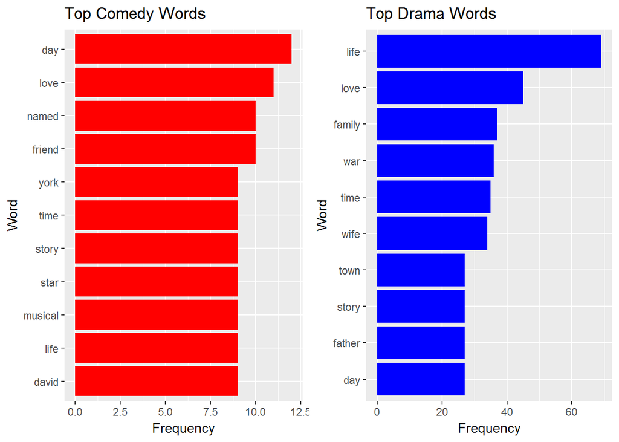

```r
# Load stop words
data("stop_words")

film_plots$plot <- as.character(film_plots$plot)

# Get tidy data frame of all words and remove stop words
tidy_plots <- film_plots %>%
  unnest_tokens(word, plot) %>%
  anti_join(stop_words, by = "word")

# Get top plot words for comedies
plot_comedy <- tidy_plots %>%
  group_by(class, word) %>%
  summarize(count = n()) %>%
  filter(class == "Comedy") %>%
  arrange(desc(count)) %>%
  top_n(10, count) %>%
  mutate(word = reorder(word, count)) %>%
  ggplot(aes(word, count)) +
  geom_bar(stat = "identity", fill = "red") + coord_flip() +
  labs(x = "Word", y = "Frequency", title = "Top Comedy Words")

# Get top plot words for dramas
plot_drama <- tidy_plots %>%
  group_by(class, word) %>%
  summarize(count = n()) %>%
  filter(class == "Drama") %>%
  arrange(desc(count)) %>%
  top_n(10, count) %>%
  mutate(word = reorder(word, count)) %>%
  ggplot(aes(word, count, fill = class)) +
  geom_bar(stat = "identity", fill = "blue") + coord_flip() +
  labs(x = "Word", y = "Frequency", title = "Top Drama Words")

grid.arrange(plot_comedy, plot_drama, ncol=2)
```

Top Drama words seem to be a good fit, but looking at top Comedy words, some appear to be more logical than others. And there is some overlap between top Drama and Comedy words. I decided to look at top words using **term frequency-inverse document frequency** method.

```r
# Count number of times each word is mentioned
plot_words <- tidy_plots %>%
  count(class, word, sort = TRUE) %>%
  ungroup()

# Count number of words per class
total_words <- plot_words %>%
  group_by(class) %>%
  summarize(total = sum(n))

# Combine two counts
plot_words <- left_join(plot_words, total_words, by = "class")

# Generate tf-idf values
plot_words <- plot_words %>%
  bind_tf_idf(word, class, n)

head(plot_words)
```

```
## # A tibble: 6 × 7
##   class   word     n total          tf   idf tf_idf
##   <chr>  <chr> <int> <int>       <dbl> <dbl>  <dbl>
## 1 Drama   life    69  9364 0.007368646     0      0
## 2 Drama   love    45  9364 0.004805639     0      0
## 3 Drama family    37  9364 0.003951303     0      0
## 4 Drama    war    36  9364 0.003844511     0      0
## 5 Drama   time    35  9364 0.003737719     0      0
## 6 Drama   wife    34  9364 0.003630927     0      0
```

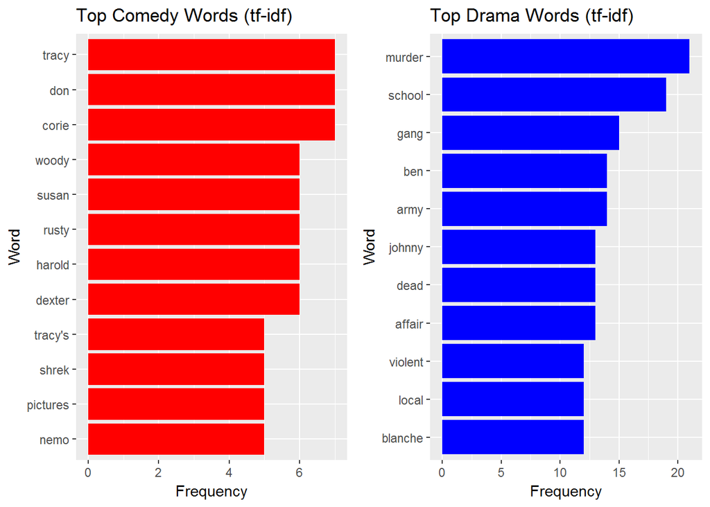

```r
plot_comedy <- plot_words %>%
  select(-total) %>%
  arrange(desc(tf_idf)) %>%
  filter(class == "Comedy") %>%
  top_n(10, tf_idf) %>%
  mutate(word = reorder(word, n)) %>%
  ggplot(aes(word, n)) +
  geom_bar(stat = "identity", fill = "red") + coord_flip() +
  labs(x = "Word", y = "Frequency", title = "Top Comedy Words (tf-idf)")

plot_drama <- plot_words %>%
  select(-total) %>%
  arrange(desc(tf_idf)) %>%
  filter(class == "Drama") %>%
  top_n(10, tf_idf) %>%
  mutate(word = reorder(word, n)) %>%
  ggplot(aes(word, n)) +
  geom_bar(stat = "identity", fill = "blue") + coord_flip() +
  labs(x = "Word", y = "Frequency", title = "Top Drama Words (tf-idf)")

grid.arrange(plot_comedy, plot_drama, ncol=2)
```

Using **tf-idf** the words are a lot more specific. However, there are clearly some words that only appear on the list because of one or two movies. For example, *shrek* or *woody* (which I thought was a reference to Woody Allen since it is in a Comedy class of critically acclaimed films, but it actually refers to Woody from *Toy Story*). I have decided to collect more film plots for a bigger data set.

## Data Scraping: Part II

As I mentioned above I was suspecting that my data set is not large enough for text mining.

### Collecting and Tidying Additional Data

To expand the film list, I went with the [National Film Registry](https://www.loc.gov/programs/national-film-preservation-board/film-registry/complete-national-film-registry-listing/) of the Library of Congress. Methodology was very similar to Part I.

```r
# Get URL and read HTML table
url <- getURL("https://www.loc.gov/programs/national-film-preservation-board/film-registry/complete-national-film-registry-listing/")
tmp <- readHTMLTable(url, which = 1)

# Select film title and release year
tmp <- tmp[, 1:2]
colnames(tmp) <- c("film", "year")

# Create empty data frame to store film plots
film_plots2 <- data.frame(film=character(),
                          year=integer(),
                          genre=character(),
                          imdbID=character(),
                          plot=character())

# Loop through all films
# Send request to OMDb API
# Process result if valid
for(i in 1:nrow(tmp)) {
  title <- as.character(tmp[i,1])
  year <- as.character(tmp[i,2])
  title <- url_encode(title)

  url <- str_c("http://www.omdbapi.com/?t=", title, "&y=", year, "&type=movie&plot=full")
  request <- getURL(url)
  if(jsonlite::validate(request)) {
    response <- request %>% spread_values(response = jstring("Response"))
    if(response$response=="True") {
      request <- request %>% spread_values(title = jstring("Title"),
                                           year = jstring("Year"),
                                           genre = jstring("Genre"),
                                           imdbID = jstring("imdbID"),
                                           plot = jstring("Plot")) %>%
        select(-document.id)
      film_plots2 <- rbind(film_plots2, request)
    }
  }
  Sys.sleep(1)
}

# Remove duplicate entries
film_plots2 <- film_plots2 %>%
  group_by(title, year, genre, imdbID, plot) %>%
  summarize()

# Add primary genre/classifier
film_plots2["class"] <- NA
film_plots2[str_detect(film_plots2$genre, "Drama")!=TRUE &
              str_detect(film_plots2$genre, "Comedy")==TRUE, 6] <- "Comedy"
film_plots2[str_detect(film_plots2$genre, "Drama")==TRUE &
              str_detect(film_plots2$genre, "Comedy")!=TRUE, 6] <- "Drama"

# Remove entries with no plot
film_plots2 <- film_plots2 %>%
  ungroup() %>%
  filter(!is.na(class)) %>%
  select(title, year, class, imdbID, plot)

# Merge original and new data frames
film_plots <- rbind(film_plots, film_plots2)

# Remove diplicate entries
film_plots <- film_plots %>%
  group_by(title, year, class, imdbID, plot) %>%
  summarize()

# Remove entries with no plot
film_plots <- film_plots %>%
  filter(plot != "N/A")

# Similarly to Part I save to file for preservation and efficiency
write.csv(film_plots, file = "film_plots2.csv", row.names = FALSE)
```

```r
film_plots <- read.csv(file = "https://raw.githubusercontent.com/ilyakats/CUNY-DATA607/master/Project%204%20Data/film_plots2.csv")

table(film_plots$class)
```

```
##
## Comedy  Drama
##    125    334
```

### Data Analysis

Now that I have more observations for each class, run the same **tf-idf** analysis as in Part I.

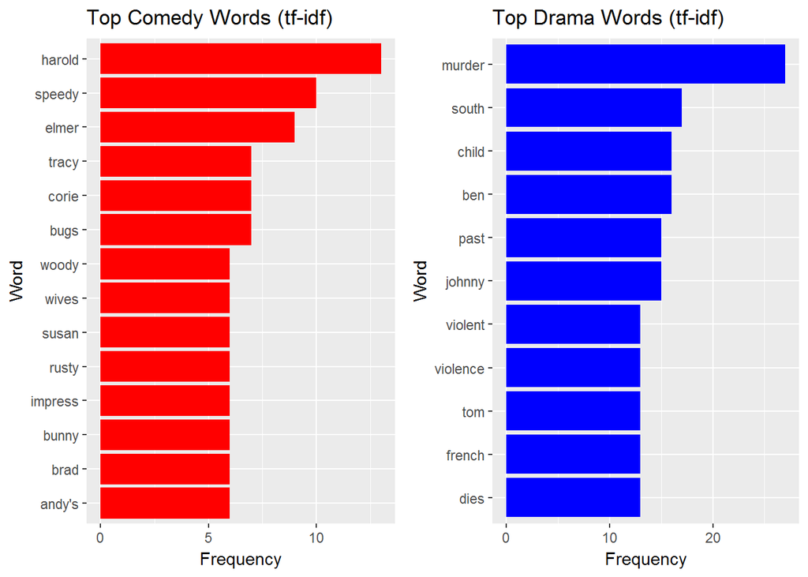

```r
data("stop_words")

film_plots$plot <- as.character(film_plots$plot)

tidy_plots <- film_plots %>%
  unnest_tokens(word, plot) %>%
  anti_join(stop_words, by = "word")

plot_words <- tidy_plots %>%
  count(class, word, sort = TRUE) %>%
  ungroup()

total_words <- plot_words %>%
  group_by(class) %>%
  summarize(total = sum(n))

plot_words <- left_join(plot_words, total_words, by = "class")

plot_words <- plot_words %>%
  bind_tf_idf(word, class, n)

plot_comedy <- plot_words %>%
  select(-total) %>%
  arrange(desc(tf_idf)) %>%
  filter(class == "Comedy") %>%
  top_n(10, tf_idf) %>%
  mutate(word = reorder(word, n)) %>%
  ggplot(aes(word, n)) +
  geom_bar(stat = "identity", fill = "red") + coord_flip() +
  labs(x = "Word", y = "Frequency", title = "Top Comedy Words (tf-idf)")

plot_drama <- plot_words %>%
  select(-total) %>%
  arrange(desc(tf_idf)) %>%
  filter(class == "Drama") %>%
  top_n(10, tf_idf) %>%
  mutate(word = reorder(word, n)) %>%
  ggplot(aes(word, n)) +
  geom_bar(stat = "identity", fill = "blue") + coord_flip() +
  labs(x = "Word", y = "Frequency", title = "Top Drama Words (tf-idf)")

grid.arrange(plot_comedy, plot_drama, ncol=2)
```

There is still some very specific words, especially for comedy, but I find the list to be a lot more interesting. I wanted to look at **bigrams**. The workflow is similar to analyzing individual words.

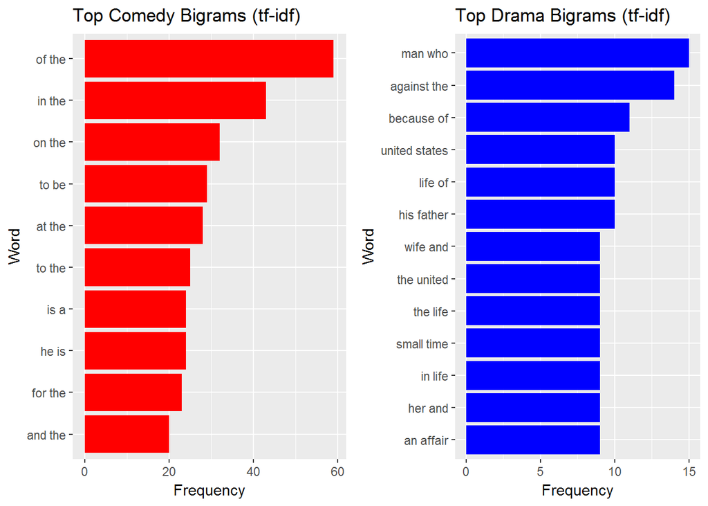

```r
plot_bigrams <- film_plots %>%
  unnest_tokens(bigram, plot, token = "ngrams", n = 2)

plot_bigrams <- plot_bigrams %>%
  count(class, bigram, sort = TRUE) %>%
  ungroup()

total_bigrams <- plot_bigrams %>%
  group_by(class) %>%
  summarize(total = sum(n))

plot_bigrams <-
  left_join(plot_bigrams, total_bigrams, by = "class")

plot_bigrams <- plot_bigrams %>%
  bind_tf_idf(bigram, class, n)

plot_comedy <- plot_bigrams %>%
  select(-total) %>%
  arrange(desc(tf_idf)) %>%
  filter(class == "Comedy") %>%
  top_n(10, tf-idf) %>%
  mutate(bigram = reorder(bigram, n)) %>%
  ggplot(aes(bigram, n)) +
  geom_bar(stat = "identity", fill = "red") + coord_flip() +
  labs(x = "Word", y = "Frequency", title = "Top Comedy Bigrams (tf-idf)")

plot_drama <- plot_bigrams %>%
  select(-total) %>%
  arrange(desc(tf_idf)) %>%
  filter(class == "Drama") %>%
  top_n(10, tf_idf) %>%
  mutate(bigram = reorder(bigram, n)) %>%
  ggplot(aes(bigram, n)) +
  geom_bar(stat = "identity", fill = "blue") + coord_flip() +
  labs(x = "Word", y = "Frequency", title = "Top Drama Bigrams (tf-idf)")

grid.arrange(plot_comedy, plot_drama, ncol=2)
```

Here again the Drama bigrams look fairly interesting, but the Comedy bigrams are full of stop words. I should separate the bigrams and get rid of all stop words for proper analysis. For now, I am proceeding to trying to model classification.

## Data Scraping: Part III

I have created the document-term matrix and ran the data through SVM, Tree and Max Entropy models as suggested in the supervised learning section of Chapter 10 of the *Automated Data Collection with R* textbook. The Max Entropy model was essentially classifying as good as a coin flip, very close to 50-50. But SVM and Tree models seemed to show better results. However, I have discovered that they were classifying all the test set as Drama. Since the number of comedies was much smaller, the models were fairly good. This was disappointing. I figured I needed to collect more comedy plots.

Since this was my third collection attempt, I decided to simply get a list of [top 100 comedy films](https://www.rottentomatoes.com/top/bestofrt/top_100_comedy_movies/) from Rotten Tomatoes, manually format it and save it as a CSV file.

Again, methodology to collect film plots is the same as in Parts I and II.

```r
# Get a list of additional comedies
tmp <- read.csv(file = "https://raw.githubusercontent.com/ilyakats/CUNY-DATA607/master/Project%204%20Data/films3.csv")

film_plots3 <- data.frame(film=character(),
                          year=integer(),
                          genre=character(),
                          imdbID=character(),
                          plot=character())

for(i in 1:nrow(tmp)) {
  title <- as.character(tmp[i,1])
  title <- url_encode(title)
  year <- as.character(tmp[i,2])

  url <- str_c("http://www.omdbapi.com/?t=", title, "&y=", year, "&type=movie&plot=full")
  request <- getURL(url)
  if(jsonlite::validate(request)) {
    response <- request %>% spread_values(response = jstring("Response"))
    if(response$response=="True") {
      request <- request %>% spread_values(title = jstring("Title"),
                                           year = jstring("Year"),
                                           genre = jstring("Genre"),
                                           imdbID = jstring("imdbID"),
                                           plot = jstring("Plot")) %>%
        select(-document.id)
      film_plots3 <- rbind(film_plots3, request)
    }
  }
  Sys.sleep(1)
}

film_plots3 <- film_plots3 %>%
  group_by(title, year, genre, imdbID, plot) %>%
  summarize()

film_plots3["class"] <- NA
film_plots3[str_detect(film_plots3$genre, "Drama")!=TRUE &
              str_detect(film_plots3$genre, "Comedy")==TRUE, 6] <- "Comedy"
film_plots3[str_detect(film_plots3$genre, "Drama")==TRUE &
              str_detect(film_plots3$genre, "Comedy")!=TRUE, 6] <- "Drama"

table(film_plots3$class)

film_plots3 <- film_plots3 %>%
  ungroup() %>%
  filter(!is.na(class)) %>%
  select(title, year, class, imdbID, plot)

film_plots <- rbind(film_plots, as.data.frame(film_plots3))

film_plots <- film_plots %>%
  group_by(title, year, class, imdbID, plot) %>%
  summarize()

film_plots <- film_plots %>%
  filter(plot != "N/A")

write.csv(film_plots, file = "film_plots3.csv", row.names = FALSE)
```

Interestingly, quite a few films Rotten Tomatoes considers comedic are actually classified as Drama according to the IMDb information.

```r
film_plots <- read.csv(file = "https://raw.githubusercontent.com/ilyakats/CUNY-DATA607/master/Project%204%20Data/film_plots3.csv")

table(film_plots$class)
```

```
##
## Comedy  Drama
##    144    331
```

I did not get a significant number of additional comedies, but there were a few additions. I decided to randomize the film list, so that the training set and test set in the corpus are spread out more evenly.

```r
film_plots <- film_plots[sample(nrow(film_plots)),]
```

## Data Analysis: Classification

```r
# Build document-term matrix
matrix <- create_matrix(film_plots$plot, language="english",
                        removeNumbers=TRUE, stemWords=TRUE, weighting=tm::weightTf)

# Create a container with existing labels
# The first 375 observations will be used to traing the models
# Remaining observations will be used to test the models
container <- create_container(matrix,
                              film_plots$class,
                              trainSize = 1:375,
                              testSize = 376:length(film_plots$class),
                              virgin = FALSE)

# Train models
svm_model <- train_model(container, "SVM")
tree_model <- train_model(container, "TREE")
maxent_model <- train_model(container, "MAXENT")

# Classify the test set
svm_out <- classify_model(container, svm_model)
tree_out <- classify_model(container, tree_model)
maxent_out <- classify_model(container, maxent_model)

# Get the actual and predicted labels
labels_out <- data.frame(plot = film_plots$plot[376:length(film_plots$plot)],
                         correct_label = film_plots$class[376:length(film_plots$class)],
                         svm = as.character(svm_out[,1]),
                         tree = as.character(tree_out[,1]),
                         maxent = as.character(maxent_out[,1]),
                         stringsAsFactors = FALSE)
```

Actual classification:

```r
table(labels_out$correct_label)
```

```
##
## Comedy  Drama
##     32     68
```

SVM model performance:

```r
table(labels_out$svm)
```

```
##
## Comedy  Drama
##     10     90
```

```r
prop.table(table(labels_out$correct_label == labels_out$svm))
```

```
##
## FALSE  TRUE
##  0.24  0.76
```

```r
table(labels_out$tree)
```

```
##
## Comedy  Drama
##      7     93
```

```r
prop.table(table(labels_out$correct_label == labels_out$tree))
```

```
##
## FALSE  TRUE
##  0.31  0.69
```

Maximum Entropy model performance:

```r
table(labels_out$maxent)
```

```
##
## Comedy  Drama
##     24     76
```

```r
prop.table(table(labels_out$correct_label == labels_out$maxent))
```

```
##
## FALSE  TRUE
##  0.26  0.74
```

Maximum Entropy model seems to perform well with this data. I wanted to get general analytics as calculated by the `RTextTools` package. Unfortunately, the `create_analytics` method only understands numeric values. 1 represents Comedy and 2 represents Drama.

```r
# Convert class labels to numeric values
classNo <- as.numeric(as.factor(film_plots$class))

# Rerun Maximum Entropy model
container <- create_container(matrix, classNo,
                              trainSize = 1:375, testSize = 376:length(film_plots$class),
                              virgin = FALSE)
maxent_model <- train_model(container, "MAXENT")
maxent_out <- classify_model(container, maxent_model)
analytics <- create_analytics(container, maxent_out, b=1)

# Output analytics summary
analytics@label_summary
```

```
##   NUM_MANUALLY_CODED NUM_CONSENSUS_CODED NUM_PROBABILITY_CODED
## 1                 32                  24                    24
## 2                 68                  76                    76
##   PCT_CONSENSUS_CODED PCT_PROBABILITY_CODED PCT_CORRECTLY_CODED_CONSENSUS
## 1             75.0000               75.0000                      46.87500
## 2            111.7647              111.7647                      86.76471
##   PCT_CORRECTLY_CODED_PROBABILITY
## 1                        46.87500
## 2                        86.76471
```

Consider mismatched classification.

```r
bad_predictions <- labels_out[labels_out$correct_label != labels_out$maxent, ]
```

|  | plot | correct_label | svm | tree | maxent |
| --- | --- | --- | --- | --- | --- |
| 1 | Young Leon Kanter dreams of being a great violinist. His parents scrape up the money for a violin and for lessons, and Leon rewards them by becoming a great player. But as an adult, Leon finds that pe… | Drama | Drama | Drama | Comedy |
| 2 | An investigative reporter sees an opportunity for the story of a lifetime when an accused murderer escapes hanging. | Comedy | Drama | Drama | Drama |
| 9 | A major heist goes off as planned, until bad luck and double crosses cause everything to unravel. | Drama | Drama | Drama | Comedy |
| 11 | Inventor Gepetto creates a wooden marionette called Pinocchio. His wish that Pinocchio be a real boy is unexpectedly granted by a fairy. The fairy assigns Jiminy Cricket to act as Pinocchio’s “conscie… | Comedy | Drama | Drama | Drama |
| 13 | Michael, Steven and Nick are young factory workers from Pennsylvania who enlist into the Army to fight in Vietnam. Before they go, Steven marries the pregnant Angela, and their wedding party also serv… | Drama | Drama | Drama | Comedy |
| 15 | Mrs. Sharpe keeps her eye on Bunny. His friend Bigelow invites him to join him in a session with the cards and chips, and tells him that he will fix it up with Mrs. Sharpe. He sends Bunny a notice tel… | Comedy | Comedy | Drama | Drama |
| 18 | Arthur is a happy drunk with no pretensions at any ambition. He is also the heir to a vast fortune which he is told will only be his if he marries Susan. He does not love Susan, but she will make some… | Comedy | Drama | Drama | Drama |
| 19 | Cat(herine) Ballou’s family farm is being threatened by the Rail Road. She sends for Kid Shelleen, finding him to be the drunkest gunfighter in the west. When her father is killed by the rail road mag… | Comedy | Drama | Drama | Drama |
| 27 | At the bottom of the depression, Tom’s mother has been out of work for months when Ed’s father loses his job. Not to burden their parents, the two high school sophomore’s decide to hop the freights an… | Drama | Comedy | Drama | Comedy |
| 32 | Berlin’s plushest, most expensive hotel is the setting where in the words of Dr. Otternschlag “People come, people go. Nothing ever happens.”. The doctor is usually drunk so he missed the fact that Ba… | Drama | Drama | Drama | Comedy |
| 33 | Poor Ella Cinders is much abused by her evil step-mother and step-sisters. When she wins a local beauty contest she jumps at the chance to get out of her dead-end life and go to Hollywood, where she i… | Comedy | Drama | Drama | Drama |
| 38 | New Yorkers Paul Bratter and Corie Bratter née Banks have just gotten married. He is a stuffed shirt just starting his career as a lawyer. She is an independently minded free spirit who prides herself… | Comedy | Comedy | Drama | Drama |
| 39 | The small state of Freedonia is in a financial mess, borrowing a huge sum of cash from wealthy widow Mrs. Teasdale. She insists on replacing the current president with crazy Rufus T. Firefly and mayhe… | Comedy | Drama | Drama | Drama |
| 40 | Chinese stowaway Mei Li (Miyoshi Umeki) arrives in San Francisco with her father to meet her fiancé, wealthy nightclub owner Sammy Fong (Jack Soo), in an arranged marriage, but the groom has his eye o… | Comedy | Drama | Drama | Drama |
| 42 | Having been discharged from the Marines for a hayfever condition before ever seeing action, Woodrow Lafayette Pershing Truesmith (Eddie Bracken) delays the return to his hometown, feeling that he is a… | Comedy | Drama | Comedy | Drama |
| 54 | Set in winter in the Old West. Charismatic but dumb John McCabe arrives in a young Pacific Northwest town to set up a whorehouse/tavern. The shrewd Mrs. Miller, a professional madam, arrives soon afte… | Drama | Drama | Drama | Comedy |
| 57 | In occupied Poland during WWII, a troupe of ham stage actors (led by Joseph Tura and his wife Maria) match wits with the Nazis. A spy has information which would be very damaging to the Polish resista… | Comedy | Drama | Drama | Drama |
| 58 | At an all-black army camp, civilian parachute maker and “hot bundle” Carmen Jones is desired by many of the men. Naturally, she wants Joe, who’s engaged to sweet Cindy Lou and about to go into pilot t… | Drama | Drama | Drama | Comedy |
| 63 | Three friends struggle to find work in Paris. Things become more complicated when two of them fall in love with the same woman. | Drama | Drama | Drama | Comedy |
| 72 | Joe Bradley is a reporter for the American News Service in Rome, a job he doesn’t much like as he would rather work for what he considers a real news agency back in the States. He is on the verge of g… | Comedy | Drama | Drama | Drama |
| 75 | Weary of the conventions of Parisian society, a rich playboy and a youthful courtesan-in-training enjoy a platonic friendship, but it may not stay platonic for long. | Comedy | Drama | Drama | Drama |
| 78 | Only the royal suite at the grandest hotel in Paris has a safe large enough for the jewels of the Grand Duchess Swana. So the three Russians who have come to sell the jewels settle into the suite unti… | Comedy | Drama | Drama | Drama |
| 83 | Tatsu is a slightly delusional painter who lives in the wilderness. He spends his days painting nothing but the image of his love, a princess he believes to have been incarnated as a dragon. His work … | Drama | Drama | Drama | Comedy |
| 85 | Set against the backdrop of 1977 Los Angeles, The Nice Guys opens when single father and licensed PI Holland March (Gosling) is hired to investigate the apparent suicide of famous porn star Misty Moun… | Comedy | Drama | Drama | Drama |
| 88 | A young neurosurgeon (Gene Wilder) inherits the castle of his grandfather, the famous Dr. Victor von Frankenstein. In the castle he finds a funny hunchback called Igor, a pretty lab assistant named In… | Comedy | Drama | Drama | Drama |
| 90 | ’Toon star Roger is worried that his wife Jessica is playing pattycake with someone else, so the studio hires detective Eddie Valiant to snoop on her. But the stakes are quickly raised when Marvin Acm… | Comedy | Drama | Drama | Drama |

## Conclusion

The results of the analysis were generally disappointing. Althought classification models were able to predict the test set with a better accuracy than a coin flip, there was still a significant number of wrong classification examples. There are two main variables. First, I have simplied film genre significantly. Original classification had much more detail than was used in the analysis. Perhaps, the method for chosing classes was flawed. This is demonstrated by a number of films that were originally classified as both comedy and drama (*dramedy* is a word for a reason). Second, film plots in this example are fairly limited. Looking over mismatched examples above, it is not hard to imagine some entries as comedic or dramatic films. I believe even human evaluators will have a hard time classifying some plots as Comedy or Drama.

Additionally, I have discovered that the size and quality of the training set can have a very significant impact on the classification model. One of the steps in the process is randomizing the list of available plots. This changes the training set every time the code is executed. This has a noticeable impact on quality of models.

Generally, I believe results I got are not acceptable to turn in for a real-life project and a lot more analysis and better training set should follow. However, as a training exercise, there is some good insight in the work performed.